# ASML EXAM Exercise 1

```r
library(ggplot2)
library(tidyverse)
```

```r
dat = read.csv('data_ex1.csv')
dat
```

| observation | country | percent_agricultural_population | calories_per_day_per_person |
| --- | --- | --- | --- |
| 1 | Switzerland | 4.0 | 3432 |
| 2 | France | 5.7 | 3273 |
| 3 | Sweden | 4.9 | 3049 |
| 4 | United States | 3.0 | 3642 |
| 5 | Russia | 14.8 | 3394 |
| 6 | China | 69.6 | 2628 |
| 7 | India | 63.8 | 2204 |
| 8 | Brazil | 26.2 | 2643 |
| 9 | Peru | 38.3 | 2192 |
| 10 | Algeria | 24.7 | 2687 |

[output cut: 1 more lines]

### a) Make a drawing of those observations

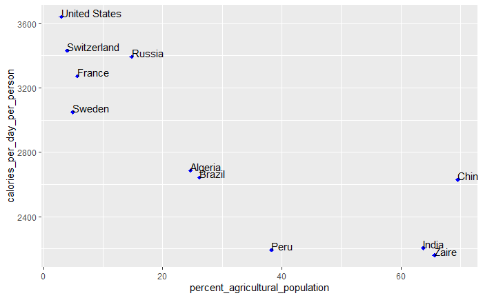

```r
ggplot(data = dat,aes(x=percent_agricultural_population,y=calories_per_day_per_person)) +
  geom_point(shape=18,color="blue",size=2)+
  geom_text(aes(label=country),hjust=0, vjust=0)
```

### b) Estimate the parameters of the model: Yi = β0 + β1.xi + εi

```r
LM = lm(calories_per_day_per_person~percent_agricultural_population,data=dat)
LM$coefficients
```

```
                    (Intercept) percent_agricultural_population
                     3346.12221                       -17.16353
```

- β0 = “(Intercept)” = 3346.12221
- β1 = “percent_agricultural_population” = -17.16353

### c) Explain the different outputs of the lm funtions used in the R software and precise the tests that are performed and how they are performed.

```r
summary(LM)
```

```
Call:
lm(formula = calories_per_day_per_person ~ percent_agricultural_population,
    data = dat)

Residuals:
    Min      1Q  Median      3Q     Max
-496.76 -224.10  -47.09  228.21  476.46

Coefficients:
                                Estimate Std. Error t value Pr(>|t|)
(Intercept)                     3346.122    144.476  23.160 2.48e-09 ***
percent_agricultural_population  -17.164      3.754  -4.572  0.00134 **
---
Signif. codes:  0 ‘***’ 0.001 ‘**’ 0.01 ‘*’ 0.05 ‘.’ 0.1 ‘ ’ 1

Residual standard error: 312.8 on 9 degrees of freedom
Multiple R-squared:  0.6991,    Adjusted R-squared:  0.6656
F-statistic: 20.91 on 1 and 9 DF,  p-value: 0.001342
```

- Residuals:

  Difference between observed value and the one predicted by the model. We look for a symmetric distribution of the residuals around 0
- Coefficients:
  - Estimate: Estimation of β0 and β1 of our model.
  - Std. Error: is the standard deviation of the estimate
  - t value: Estimate / Std. error
  - Pr(>|t|): probability to observe value larger than t

    Student test performed for each parameter individually: H0 -> β1 = 0, H1 -> β1 != 0

    $$P_{H0}\left ( \left | \widehat{\beta _{1}} \right |>t \right )
    with:
    \widehat{\beta _{1}} = \frac{\sum_{i=1}^{n}\left ( X_{i} - \bar{X_{n}} \right )(Y_{i} - \bar{Y_{n}})}{\sum_{i=1}^{n}\left ( X_{i} - \bar{X_{n}} \right )^{2}}$$
- Residual standard error:

  estimation of parameter σ for residuals with distribution N(0;σ)
- Multiple R-squared:

  $$R^{2} =\frac{\sum_{i=1}^{n}\left ( \widehat{Y_{i}}-\overline{Y_{n}} \right )^{2}}{\sum_{i=1}^{n}\left ( Y_{i}-\overline{Y_{n}} \right )^{2}}$$
  also called coefficient of determination = variance explained / total variance = 1 - (variance of residuals / variance total)

  gives information about goodness of fit of the model, should be close to one to be a correct linear model
- Adjusted R-squared:

  corrected version of R², taking unbiased estimator for the variances

  $$R_{adj}^{2}=1-\frac{n-1}{n-p-1}\left ( 1-R^{2} \right ) with: p\ nb\ of\ parameters\ in\ model$$
- F-statistic: it’s a global Fisher Test with H0: β1=β2=…βp=0 , H1: at least one parameter is different from 0.

  observed value of F where
  $$F =\frac{\frac{\left \| \widehat{Y_{1}}-\overline{Y_{n}} \right \|^{2}}{Rk(X)-1}}{\frac{\left \| Y-\widehat{Y_{1}} \right \|^{2}}{n -Rk(X)}}$$
  - p-value:

    p-value associated with the test:
    $$P(F(Rk(X)-1);n-Rk(X) > F_{obs})$$

    if p-value > α : do not reject H0

    if p-value < α : we reject H0

### d) Construt a confidence interval at 95% for the regression curve, at a point x0

The Confidence interval for E[Y] at point x0 with confidence level 100(1-α)% is:

$$\left [ \widehat{\beta _{0}}+\widehat{\beta _{1}}\pm \widehat{\sigma _{n}}\sqrt{\frac{1}{n}+\frac{(x_{0}-\overline{X_{n}})^{2}}{\sum (X_{i}-\overline{X_{n}})^{2}}} t_{1-\frac{\alpha }{2};n-2}\right ]$$

```r
pred = predict(LM, dat,interval="confidence")
pred
```

```
        fit      lwr      upr
1  3277.468 2975.554 3579.382
2  3248.290 2956.411 3540.170
3  3262.021 2965.465 3558.577
4  3294.632 2986.651 3602.612
5  3092.102 2846.370 3337.834
6  2151.540 1747.213 2555.868
7  2251.089 1887.665 2614.512
8  2896.438 2681.598 3111.277
9  2688.759 2461.696 2915.822
10 2922.183 2705.486 3138.880
11 2218.478 1841.875 2595.081
```

### e) Draw the points, the regression curve and the curves associated to the confident interval on the same graphic.

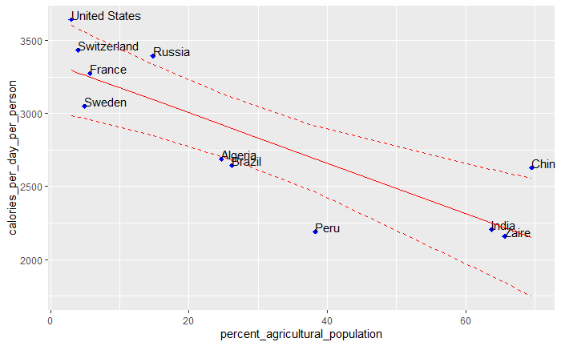

```r
dat2 = cbind(dat,pred)
ggplot(data=dat2 ) +
  geom_point(aes(x=percent_agricultural_population, y=calories_per_day_per_person),shape=18,color="blue",size=2)+
  geom_text(aes(x=percent_agricultural_population, y=calories_per_day_per_person,label=country),hjust=0, vjust=0)+
  geom_line(aes(x=percent_agricultural_population, y=fit),col="red") +
  geom_line(aes(x=percent_agricultural_population, y=lwr),linetype = "dashed",col="red") +
  geom_line(aes(x=percent_agricultural_population, y=upr),linetype = "dashed",col="red")
```